# HumanActivityRecognition-Prediction

Shashank Sane

April 20, 2017

## Introduction

Using devices such as Jawbone Up, Nike FuelBand, and Fitbit is now possible to collect a large amount of data about personal activity relatively inexpensively. These type of devices are part of the quantified self movement - a group of enthusiasts who take measurements about themselves regularly to improve their health, to find patterns in their behavior, or because they are tech geeks. One thing that people regularly do is quantify how much of a particular activity they do, but they rarely quantify how well they do it.

In this project, we have used data from accelerometers on the belt, forearm, arm, and dumbell of 6 participant They were asked to perform barbell lifts correctly and incorrectly in 5 different ways. The five ways are exactly according to the specification (Class A), throwing the elbows to the front (Class B), lifting the dumbbell only halfway (Class C), lowering the dumbbell only halfway (Class D) and throwing the hips to the front (Class E). Only Class A corresponds to correct performance. The goal of this project is to predict the manner in which they did the exercise, i.e., Class A to E. More information is available from the website here: http://groupware.les.inf.puc-rio.br/har (see the section on the Weight Lifting Exercise Dataset).

### load required libraries

```r
library(plyr)
library(dplyr)
library(tidyr)
library(ggplot2)
library(caret)
library(rpart)
library(randomForest)
```

### load the data file

```r
# url of the training data file
fileURL.Training <- "https://d396qusza40orc.cloudfront.net/predmachlearn/pml-training.csv"

# url of the testing data file
fileURL.Test <- "https://d396qusza40orc.cloudfront.net/predmachlearn/pml-testing.csv"

# Destination training file name
DestinationTrainFile <- "pml-training.csv"

# Download training file if does not exist in workspace
if (!file.exists(DestinationTrainFile)){
  download.file(fileURL.Training, DestinationTrainFile)
}

## read file into training data frame
dfTrain <- read.csv(DestinationTrainFile,header = TRUE,stringsAsFactors = FALSE,na.strings = "NA")

# Destination Testing file name
DestinationTestFile <- "pml-testing.csv"

# Download Testing file if does not exist in workspace
if (!file.exists(DestinationTestFile)){
  download.file(fileURL.Test, DestinationTestFile)
}

## read file into Testing data frame
dfTest <- read.csv(DestinationTestFile,header = TRUE,stringsAsFactors = FALSE,na.strings = "NA")
```

### Data Cleaning and feature building

```r
# check str (donot output)
# str(dfTrain)

# Convert Classe into factor variable for both training and test data
dfTrain$classe <- as.factor(dfTrain$classe)

# remove columns which are not required:
# we dont require row labels or user name or new window
dfTrain <- subset(dfTrain,select = -c(user_name,new_window,X,raw_timestamp_part_1,raw_timestamp_part_2,cvtd_timestamp,num_window))

# replace any "#DIV/0!" value with NA in both training and test set
dfTrain[dfTrain=="#DIV/0"]<-NA
dfTest[dfTest=="#DIV/0"]<-NA

# replace any empty values with NA
dfTrain[dfTrain==""]<-NA
dfTest[dfTest==""]<-NA

# we can see that there are lot of coulmns which are with more than 90% NA values
# remove columns with more tha 95% NA values
dfTrain <- dfTrain[, -which(colMeans(is.na(dfTrain)) > 0.95)]

# Create partition in test set 90% for training and 10% for validation
inTrain <- createDataPartition(dfTrain$classe,p=0.9,list=FALSE)

# Create training and testing subsets from training data.
dfSubTrain <- dfTrain[inTrain,]
dfSubTest <- dfTrain[-inTrain,]
```

### Training and testing models

```r
#load libraries to do parallel process
library(parallel)
library(doParallel)

# Define training control
# I would be using 10 fold cross validation
fitControl <- trainControl(method = "cv",
                           number = 10,
                           allowParallel = TRUE)
```

### regression trees

```r
# we will first try to train regression tree model and check the out of sample accuracy
# Initiate cluster and register for parallel processing
cluster <- makeCluster(detectCores() - 1) # leave one core out for CPU
registerDoParallel(cluster)

# start stop watch to start measuring time for model training
ptm <- proc.time()

# train a Regression Tree model on the training subset
fit.rpart <- train(classe~., method="rpart",data=dfSubTrain,trControl = fitControl)

# take the difference between start time and end time to measure the time take for model training
proc.time() -ptm
```

```
##    user  system elapsed
##   12.62    0.16   30.19
```

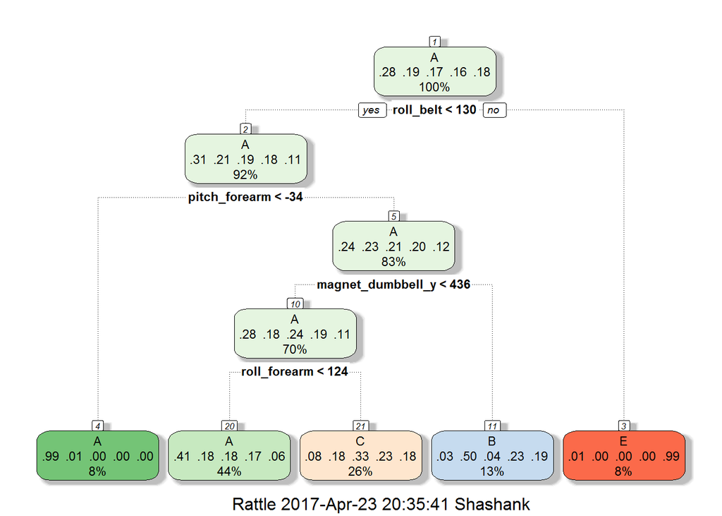

```r
# Stop our created cluster and De-register from parallel processing
stopCluster(cluster)
registerDoSEQ()

# load library rattle
library(rattle)

# check the regression tree created
fancyRpartPlot(fit.rpart$finalModel)
```

```r
# we can see that our model is not able to classify model label D,however we do get an idea about the important predictors

# Check the out of sample prediction accuracy
confusionMatrix(dfSubTest$classe,predict(fit.rpart,dfSubTest))$overall[1]
```

```
##  Accuracy
## 0.4836735
```

```r
# it also has a very low accuracy, so we would be trying with random forest
```

### Random Forest

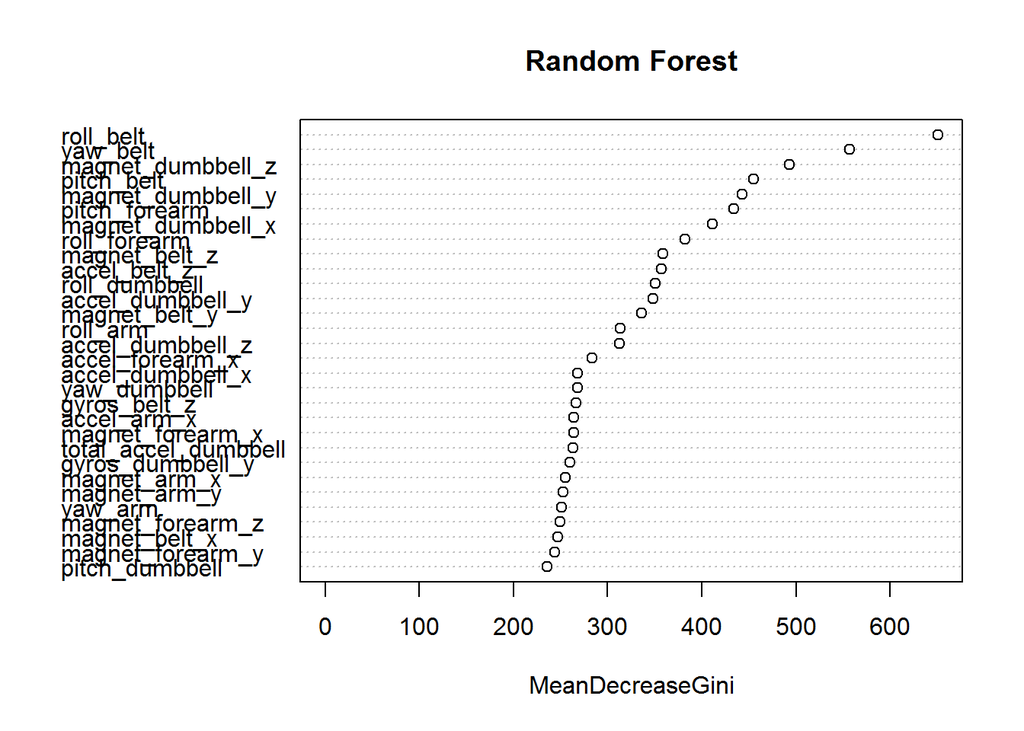

```r
# Check if the model is saved from the previous run
# if not then train the model.
if (!file.exists("fitrf.RData"))
{

  # Initiate cluster and register for parallel processing
  cluster <- makeCluster(detectCores() - 1) # leave one core out for CPU
  registerDoParallel(cluster)

  # start stop watch to start measuring time for model training
  ptm <- proc.time()

  # fit.gbm <- train(classe~., method="gbm",data=dfSubTrain,trControl = fitControl)

  # train a Random Forest model on the training subset
  fit.rf <- train(classe~., method="rf",data=dfSubTrain,trControl = fitControl)

  # take the difference between start time and end time to measure the time take for model    training
  proc.time() -ptm

  # Stop our created cluster and De-register from parallel processing
  stopCluster(cluster)
  registerDoSEQ()

  # save the trained model on disk
  save(fit.rf,file ="fitrf.RData")

}else {

  # else load the model from disk

  load("fitrf.RData")
}

# plot variable importance:
varImpPlot(fit.rf$finalModel,main = "Random Forest")
```

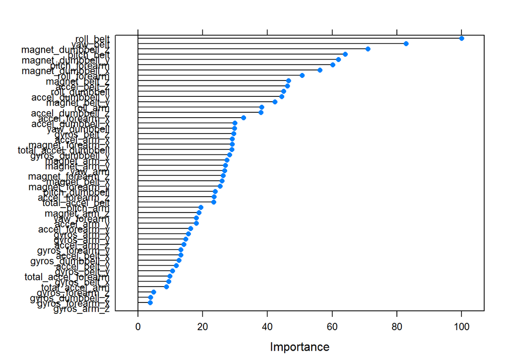

```r
# plot varibales of importance
plot(varImp(fit.rf))
```

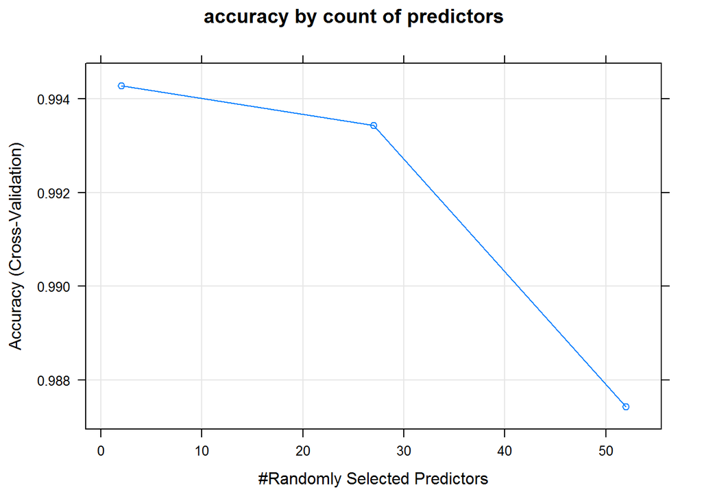

```r
# plot accuray by predictor count
plot(fit.rf,main=" accuracy by count of predictors")
```

```r
# Check the out of sample prediction accuracy
confusionMatrix(dfSubTest$classe,predict(fit.rf,dfSubTest))$overall[1]
```

```
##  Accuracy
## 0.9989796
```

```r
# predict on the test sample
predict(fit.rf,dfTest)
```

```
##  [1] B A B A A E D B A A B C B A E E A B B B
## Levels: A B C D E
```